# HTC Analysis

Mickey Rafa

FallQ 2016 - SpringQ 2017

# Executive Summary

The Human Trafficking Center (HTC) coded 156 categorical variables from the U.S. Department of State’s *Trafficking in Persons* Report (or “TIPs Report”). Each of these variables have been conceptualized as components of larger indices that capture different types of trafficking or government response to trafficking. “Trafficking Presence” (or **trafpres**) contains variables on the types of trafficking, such as labor, marriage, and sex trade, while “Government Response” (or **govrespons**) contains variables on the types of response to trafficking, such as legal protections or services provided to victims.

# Introduction

Human trafficking is inherently a difficult phenomenon to measure. Much like other types of illicit activity, such as organized crime, it is difficult to measure the magnitude of human trafficking because it is by its nature avoiding detection. Unlike organized crime, though, human trafficking can carry an added stigma on its victims that can even impede self-reporting.

While measuring the magnitude of these crimes across countries and time is problematic, the categorical measurement (or, the existence or absence of these crimes) is much more achievable and may lend itself better to research.

## Trafpres variables

|  | IOS3 | country | country_old | year | O_labor | O_childlabor | O_sex | O_childsex | O_cstourism | O_domestic | O_begging | T_labor | T_childlabor | T_sex | T_childsex | T_cstourism | T_domestic | T_begging | D_labor | D_childlabor | D_sex | D_childcse | D_cstourism | D_domestic | D_begging | I_labor | I_childlabor | I_sex | I_childsex | … |
| --- | --- | --- | --- | --- | --- | --- | --- | --- | --- | --- | --- | --- | --- | --- | --- | --- | --- | --- | --- | --- | --- | --- | --- | --- | --- | --- | --- | --- | --- | --- |
| 1 | AFG | Afghanistan | Afghanistan | 2006 | 0 | 0 | 1 | 1 | 0 | 1 | 0 | 1 | 0 | 1 | 0 | 0 | 0 | 0 | 0 | 0 | 0 | 0 | 0 | 0 | 0 | 0 | 1 | 1 | 1 | … |
| 2 | ALB | Albania | Albania | 2006 | 0 | 0 | 0 | 0 | 0 | 0 | 1 | 0 | 0 | 0 | 0 | 0 | 0 | 0 | 0 | 0 | 0 | 0 | 0 | 0 | 0 | 0 | 1 | 0 | 0 | … |
| 3 | DZA | Algeria | Algeria | 2006 | 1 | 1 | 1 | 0 | 0 | 1 | 0 | 0 | 0 | 0 | 0 | 0 | 0 | 0 | 1 | 0 | 1 | 0 | 0 | 0 | 1 | 0 | 0 | 0 | 0 | … |
| 4 | AGO | Angola | Angola | 2006 | 0 | 0 | 0 | 1 | 0 | 1 | 0 | 0 | 0 | 0 | 0 | 0 | 0 | 0 | 0 | 0 | 0 | 0 | 0 | 0 | 0 | 0 | 1 | 0 | 1 | … |
| 5 | ARG | Argentina | Argentina | 2006 | 0 | 0 | 1 | 1 | 0 | 0 | 0 | 0 | 0 | 0 | 0 | 0 | 0 | 0 | 1 | 0 | 1 | 1 | 0 | 0 | 0 | 0 | 0 | 1 | 0 | … |
| 6 | ARM | Armenia | Armenia | 2006 | 0 | 0 | 1 | 1 | 0 | 0 | 0 | 0 | 0 | 1 | 1 | 0 | 0 | 0 | 0 | 0 | 1 | 1 | 0 | 0 | 0 | 0 | 0 | 0 | 0 | … |

The number of countries coded by year increases across time. In 2001, 83 countries were coded in the HTC dataset; for 2015, 202 countries were coded. This growth is important to bear in mind for historical analysis.

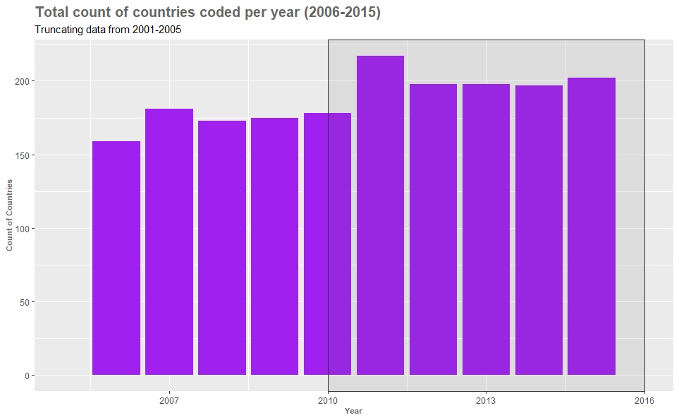

| HTCrawtp$year | HTCrawtp$trafpresSUM |
| --- | --- |
| 2006 | 159 |
| 2007 | 181 |
| 2008 | 173 |
| 2009 | 175 |
| 2010 | 178 |
| 2011 | 217 |
| 2012 | 198 |
| 2013 | 198 |
| 2014 | 197 |
| 2015 | 202 |

The summed values for all observations in a given year are visualized below. This shows that there is potentially a “reporting bias” at play – there’s clearly a very significant time component that may be driven by an increased intensity in reporting some of these types of trafficking since 2001. There’s an article by Farris that describes this issue in human rights data and presents a latent variable approach as a solution. This approach should be evaluated to see if we can address this possible instrument bias.

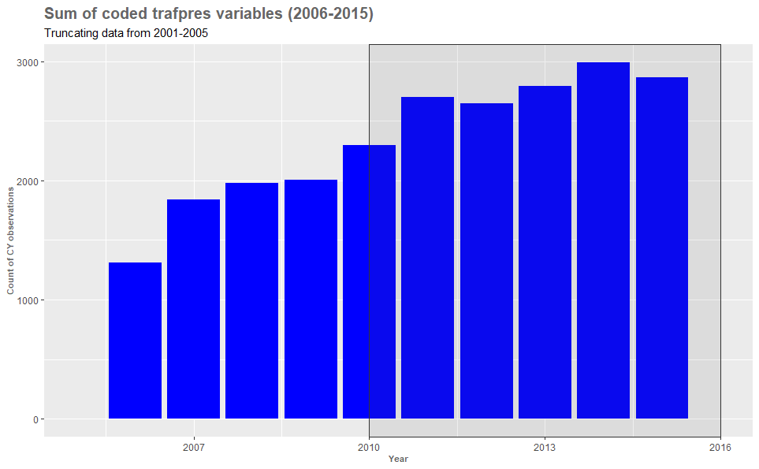

| HTCrawtp$year | HTCrawtp$trafpresSUM |
| --- | --- |
| 2006 | 1314 |
| 2007 | 1840 |
| 2008 | 1982 |
| 2009 | 2007 |
| 2010 | 2298 |
| 2011 | 2702 |
| 2012 | 2649 |
| 2013 | 2794 |
| 2014 | 2990 |
| 2015 | 2866 |

## Correlation Analysis of **trafpres** Component Variables

The default setting of the `cor_auto()` function is to produce a Pearson’s correlation matrix. However, if this function is fed binary or ordinal data, it will produce the polychoric correlation matrix. Given that our raw component data is comprised of binary data, a polychoric correlation matrix is required.

```r
#Build polychoric correlation matrix
trafpresCor <- qgraph::cor_auto(trafprevComponents, detectOrdinal = TRUE,
                        forcePD = FALSE)
```

```
Variables detected as ordinal: O_labor; O_childlabor; O_sex; O_childsex; O_cstourism; O_domestic; O_begging; T_labor; T_childlabor; T_sex; T_childsex; T_cstourism; T_domestic; T_begging; D_labor; D_childlabor; D_sex; D_childcse; D_cstourism; D_domestic; D_begging; I_labor; I_childlabor; I_sex; I_chi…
```

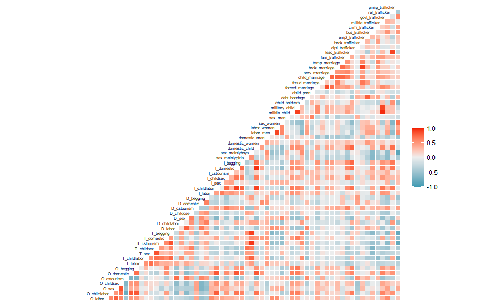

This bird’s eye view illustrates that there are some variables of these 59 **trafpres** components that are highly correlated with one another. These coefficients could be used in confirmatory factor analysis (CFA) to determine whether the theorized indices within the dataset seem to cluster. Before experimenting with CFA, we’ll experiment with principal components analysis (PCA) as a dimension reduction and index building technique.

These data are complex to analyze together. Some variables, such as **pimp_trafficker** are very commonly coded (1,833), while other variables, like **sex_mainlyboys** are rarely used (only 6 times total in the dataset). With a dataset this unbalanced, PCA will artificially use the uncommon variables to find orthoganals.

| variable | Number of Occurrences |
| --- | --- |
| T_cstourism | 4 |
| sex_mainlyboys | 6 |
| T_begging | 11 |
| child_soldiers | 21 |
| child_porn | 24 |
| I_cstourism | 26 |
| T_childlabor | 34 |
| domestic_men | 35 |
| serv_marriage | 55 |
| T_domestic | 57 |

[output cut: 8 more lines]

```r
HTCdata_v2 <- HTCdata %>%
  group_by(country, year) %>%
  select(c(vars_greater_than_100$variable)) %>%
  ungroup()
```

# Analysis of Variables

## Principal Components Analysis (PCA) testing - April 2017

Principal Components Analysis can be used to trim the component variables of the HTC indices into a more parsimonious set of variables that explain the total variation in the respective index. This section will illustrate that dimension reduction is possible on the **trafprev** component variables.

The first step in PCA is to produce a scree plot. This step tests the data to see how many principal components might be present in the data (or, put another way, how many principal components are necessary to maximize the explained variance in the data). PCA can help us trim the redundancy out of the dataset to reach a more parsimonious set of principal components.

### All variables

```r
#Build polychoric correlation matrix
all_vars_polychoric <- qgraph::cor_auto(trafprevComponents, detectOrdinal = TRUE, forcePD = FALSE)
```

```
Variables detected as ordinal: O_labor; O_childlabor; O_sex; O_childsex; O_cstourism; O_domestic; O_begging; T_labor; T_childlabor; T_sex; T_childsex; T_cstourism; T_domestic; T_begging; D_labor; D_childlabor; D_sex; D_childcse; D_cstourism; D_domestic; D_begging; I_labor; I_childlabor; I_sex; I_chi…
```

```r
#Produce scree plot of PCA results and identify PCs > 1
all_vars_pca_scree <- fa.parallel(all_vars_polychoric, fa="pc", n.iter=100, show.legend = TRUE,
                       main="Scree Plot of Principal Components for All variables")
```

[output not shown]

```
Parallel analysis suggests that the number of factors =  NA  and the number of components =  9
```

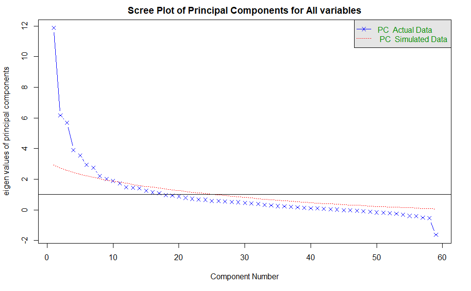

```r
abline(h=1)
```

```r
#Show PCA results
all_vars_pca_kaiser <- principal(all_vars_polychoric, nfactors=17, rotate="varimax", scores = TRUE)
```

```
Matrix was not positive definite, smoothing was doneMatrix was not positive definite, smoothing was doneNaNs produced
```

```r
all_vars_pca_kaiser[[5]]
```

```
Loadings:
                   RC2    RC1    RC7    RC5    RC4    RC3
O_labor             0.157  0.124  0.138  0.153  0.360  0.469
O_childlabor        0.132  0.444  0.372         0.239  0.269
O_sex                      0.110                0.811  0.156
O_childsex          0.143  0.239  0.251  0.172  0.697
O_cstourism               -0.293 -0.155        -0.231  0.153
O_domestic                 0.649  0.218         0.148
O_begging           0.193  0.110  0.328
T_labor             0.665  0.151                       0.338
T_childlabor        0.863  0.172        -0.167  0.276  0.158
T_sex               0.683                0.167  0.291
T_childsex          0.706 -0.144 -0.121  0.100  0.344
T_cstourism         0.985  0.208  0.281  0.211 -0.236
T_domestic          0.572  0.415  0.437
T_begging           0.758 -0.100                      -0.289
D_labor                          -0.124        -0.257  0.662
D_childlabor        0.281  0.351  0.126                0.240
D_sex               0.102 -0.120                       0.153
D_childcse          0.257  0.141         0.112
D_cstourism                0.371         0.627  0.138
D_domestic                               0.133 -0.271  0.144
D_begging           0.277 -0.123         0.127 -0.105
I_labor                    0.214  0.318         0.102  0.307
I_childlabor        0.117  0.735  0.277         0.127
I_sex                                           0.195  0.176
I_childsex                 0.598  0.145  0.238  0.115
I_cstourism         0.103  0.242
I_domestic                 0.828  0.175  0.111
I_begging                  0.272  0.161  0.255         0.128
sex_mainlygirls     0.247               -0.107  0.158 -0.157
sex_mainlyboys      0.877         0.168        -0.116
domestic_child             0.816  0.197  0.168
domestic_women             0.339         0.148         0.157
domestic_men        0.335               -0.142         0.164
labor_men                                       0.179  0.784
labor_women                                     0.260  0.818
sex_women                 -0.132 -0.146         0.689  0.175
sex_men             0.152                              0.173
militia_child              0.210  0.929
```

[output cut: 137 more lines]

```
rel_trafficker      0.104                0.143  0.134
 [ reached getOption("max.print") -- omitted 1 row ]

                 RC2   RC1   RC7   RC5   RC4   RC3  RC12  RC15
SS loadings    5.953 5.270 3.959 3.445 3.236 3.217 3.024 3.005
Proportion Var 0.101 0.089 0.067 0.058 0.055 0.055 0.051 0.051
Cumulative Var 0.101 0.190 0.257 0.316 0.371 0.425 0.476 0.527
                RC17   RC8  RC13   RC9  RC16   RC6  RC14  RC10
SS loadings    2.813 2.738 2.666 2.420 2.397 2.317 2.290 1.952
Proportion Var 0.048 0.046 0.045 0.041 0.041 0.039 0.039 0.033
Cumulative Var 0.575 0.621 0.667 0.708 0.748 0.787 0.826 0.859
                RC11
SS loadings    1.782
Proportion Var 0.030
Cumulative Var 0.890
```

```r
#Show PCA results
#based on the scree plot, you could make the case for a 7 factor solution (one point left of the elbow)
all_vars_pca_scree_test <- principal(all_vars_polychoric, nfactors=7, rotate="varimax", scores = TRUE)
```

```
Matrix was not positive definite, smoothing was doneMatrix was not positive definite, smoothing was done
```

```r
all_vars_pca_scree_test[[5]]
```

```
Loadings:
                   RC1    RC2    RC5    RC4    RC3    RC7
O_labor             0.108  0.133         0.678         0.346
O_childlabor        0.576  0.106         0.383 -0.182  0.407
O_sex               0.126  0.193  0.165  0.691 -0.304
O_childsex          0.277  0.265  0.253  0.500 -0.354  0.135
O_cstourism        -0.257         0.233 -0.168  0.594 -0.301
O_domestic          0.589                0.263         0.480
O_begging           0.329  0.173  0.104  0.210 -0.149  0.445
T_labor                    0.479         0.310  0.250
T_childlabor        0.376  0.842 -0.104
T_sex              -0.169  0.670  0.207  0.304
T_childsex                 0.863  0.150  0.136        -0.222
T_cstourism         0.337  0.971  0.175 -0.202  0.340  0.408
T_domestic          0.292  0.462                0.276  0.644
T_begging           0.103  0.761  0.108 -0.390         0.149
D_labor            -0.114         0.102  0.188  0.745 -0.156
D_childlabor        0.493  0.264        -0.100  0.361
D_sex              -0.149  0.192         0.224  0.579 -0.266
D_childcse          0.233  0.398  0.162  0.101  0.335 -0.233
D_cstourism         0.292 -0.126  0.346  0.320 -0.166 -0.124
D_domestic          0.146         0.102 -0.204  0.803
D_begging           0.211  0.286  0.162 -0.263  0.466 -0.116
I_labor             0.173                0.338         0.330
I_childlabor        0.754         0.159  0.193 -0.108  0.288
I_sex                      0.140  0.101  0.377
I_childsex          0.471         0.235  0.279
I_cstourism         0.183         0.118  0.243
I_domestic          0.787                              0.257
I_begging           0.595         0.297  0.154
sex_mainlygirls    -0.112  0.505 -0.106        -0.114
sex_mainlyboys      0.105  0.865        -0.181  0.211  0.298
domestic_child      0.798         0.186                0.236
domestic_women      0.303         0.129  0.194  0.533  0.345
domestic_men               0.365 -0.354         0.501  0.309
labor_men                                0.704  0.426  0.162
labor_women                              0.641  0.376
sex_women          -0.193         0.239  0.715  0.197 -0.318
sex_men                    0.196         0.110  0.254
militia_child       0.153         0.260                0.778
```

[output cut: 71 more lines]

```
teac_trafficker    -0.243
dipl_trafficker     0.362
brok_trafficker
empl_trafficker
bus_trafficker      0.138
crim_trafficker     0.242
militia_trafficker  0.242
govt_trafficker     0.198
rel_trafficker
pimp_trafficker     0.171

                 RC1   RC2   RC5   RC4   RC3   RC7   RC6
SS loadings    6.453 6.162 5.582 5.344 5.004 4.729 3.592
Proportion Var 0.109 0.104 0.095 0.091 0.085 0.080 0.061
Cumulative Var 0.109 0.214 0.308 0.399 0.484 0.564 0.625
```

```r
#Show PCA results
#more conservative interpretation of scree plot
#you could make the case for a 4 factor solution (one point left of the elbow)
all_vars_pca_scree_test_2 <- principal(all_vars_polychoric, nfactors=4, rotate="varimax", scores = TRUE)
```

```
Matrix was not positive definite, smoothing was doneMatrix was not positive definite, smoothing was doneNaNs produced
```

```r
all_vars_pca_scree_test_2[[5]]
```

```
Loadings:
                   RC1    RC3    RC2    RC4
O_labor             0.298  0.625  0.191 -0.275
O_childlabor        0.656  0.193  0.124 -0.329
O_sex               0.231  0.622  0.187 -0.406
O_childsex          0.405  0.448  0.242 -0.357
O_cstourism        -0.341  0.112         0.709
O_domestic          0.705  0.156        -0.107
O_begging           0.489         0.165 -0.265
T_labor                    0.299  0.521
T_childlabor        0.222         0.831
T_sex              -0.151  0.326  0.618
T_childsex         -0.161  0.135  0.792
T_cstourism         0.476         1.050  0.400
T_domestic          0.515         0.540  0.129
T_begging           0.184 -0.283  0.775  0.206
D_labor            -0.246  0.336         0.617
D_childlabor        0.295 -0.129  0.306  0.353
D_sex              -0.313  0.342  0.213  0.476
D_childcse                 0.183  0.405  0.378
D_cstourism         0.335  0.410 -0.131
D_domestic                        0.116  0.762
D_begging                 -0.136  0.295  0.565
I_labor             0.350  0.389  0.140
I_childlabor        0.825  0.150
I_sex               0.107  0.458  0.204
I_childsex          0.545  0.340
I_cstourism         0.230  0.355         0.162
I_domestic          0.793                0.133
I_begging           0.617  0.204         0.168
sex_mainlygirls    -0.156         0.487 -0.136
sex_mainlyboys      0.227         0.917  0.240
domestic_child      0.796                0.152
domestic_women      0.363  0.245  0.109  0.384
domestic_men                      0.486  0.213
labor_men                  0.724         0.119
labor_women                0.640         0.110
sex_women          -0.271  0.787
sex_men                    0.221  0.302  0.250
militia_child       0.637  0.202
```

[output cut: 11 more lines]

```
teac_trafficker     0.640 -0.240
dipl_trafficker     0.135                0.487
brok_trafficker     0.192  0.489         0.274
empl_trafficker            0.398         0.364
bus_trafficker      0.383  0.369 -0.184  0.283
crim_trafficker     0.187  0.341 -0.107  0.392
militia_trafficker  0.640  0.145
govt_trafficker     0.268  0.468 -0.129
rel_trafficker      0.575 -0.193  0.131  0.181
pimp_trafficker            0.690 -0.317

                 RC1   RC3   RC2   RC4
SS loadings    9.251 6.666 6.556 5.152
Proportion Var 0.157 0.113 0.111 0.087
Cumulative Var 0.157 0.270 0.381 0.468
```

### Origin, Transit, & Destination Variables

First, I’ll start by only including the origin, transit, and destination variables.

```r
#Build polychoric correlation matrix
trafpresCor_pca <- qgraph::cor_auto(trafprevComponents[,c('O_labor', 'O_childlabor', 'O_sex', 'O_cstourism', 'O_domestic', 'O_begging', 'T_labor', 'T_childlabor', 'T_sex', 'T_childsex', 'T_cstourism', 'T_domestic', 'T_begging', 'D_labor', 'D_childlabor', 'D_sex', 'D_cstourism', 'D_domestic', 'D_begging')], detectOrdinal = TRUE, forcePD = FALSE)
```

```
Variables detected as ordinal: O_labor; O_childlabor; O_sex; O_cstourism; O_domestic; O_begging; T_labor; T_childlabor; T_sex; T_childsex; T_cstourism; T_domestic; T_begging; D_labor; D_childlabor; D_sex; D_cstourism; D_domestic; D_begging
```

```
In smc, smcs < 0 were set to .0
In smc, smcs < 0 were set to .0
In smc, smcs < 0 were set to .0
```

```
Parallel analysis suggests that the number of factors =  NA  and the number of components =  4
```

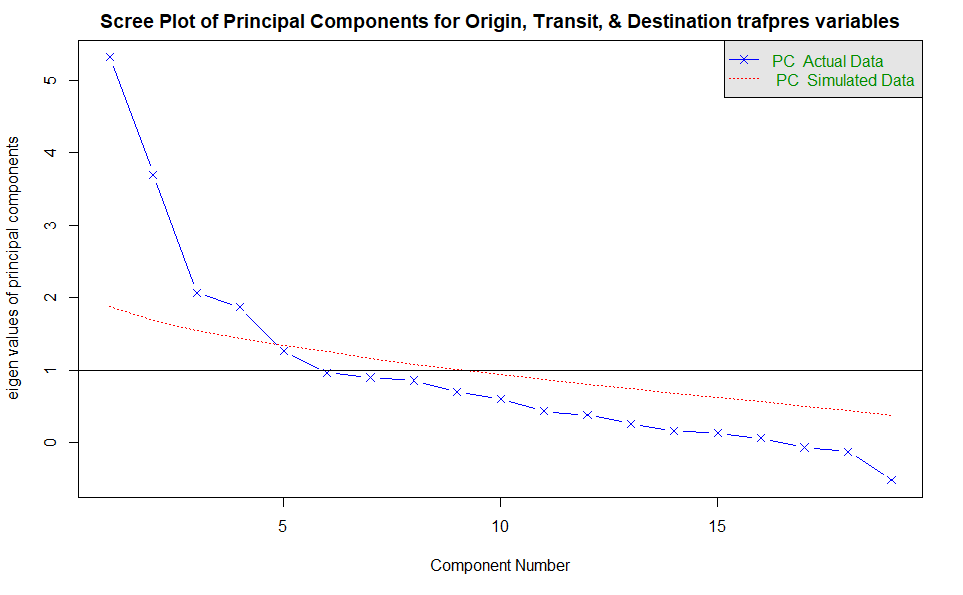

```
Matrix was not positive definite, smoothing was doneMatrix was not positive definite, smoothing was doneNaNs produced
```

```
Loadings:
             RC3    RC2    RC1    RC4    RC6    RC5
O_labor              0.293                0.890
O_childlabor         0.693        -0.160  0.300  0.285
O_sex         0.127  0.154        -0.167  0.764  0.229
O_cstourism  -0.100 -0.422  0.175  0.530        -0.474
O_domestic   -0.136  0.815  0.100         0.232  0.129
O_begging            0.802        -0.143
T_labor       0.609  0.106         0.374  0.330 -0.189
T_childlabor  0.660  0.227  0.596 -0.211  0.139
T_sex         0.915        -0.111  0.116  0.103  0.105
T_childsex    0.934         0.207
T_cstourism   0.614  0.457  0.691  0.373  0.183 -0.185
T_domestic    0.363  0.754  0.219  0.186        -0.293
T_begging     0.447  0.120  0.674 -0.182        -0.481
D_labor             -0.177  0.142  0.840
D_childlabor         0.114  0.822  0.172         0.322
D_sex         0.329                0.743 -0.147  0.132
D_cstourism                               0.259  0.691
D_domestic           0.128  0.333  0.717 -0.282
D_begging                   0.781  0.241        -0.149

                 RC3   RC2   RC1   RC4   RC6   RC5
SS loadings    3.392 3.009 2.859 2.622 1.889 1.422
Proportion Var 0.179 0.158 0.150 0.138 0.099 0.075
Cumulative Var 0.179 0.337 0.487 0.625 0.725 0.800
```

### Traffickers, targets, and types

```r
#Build polychoric correlation matrix
trafpresCor_pca2 <- qgraph::cor_auto(trafprevComponents[,c('O_labor', 'O_sex', 'T_labor', 'T_sex', 'D_labor', 'D_sex', 'labor_men', 'labor_women', 'sex_women', 'sex_men', 'fam_trafficker', 'teac_trafficker', 'dipl_trafficker', 'brok_trafficker', 'empl_trafficker', 'bus_trafficker', 'crim_trafficker', 'militia_trafficker', 'govt_trafficker', 'rel_trafficker', 'pimp_trafficker')], detectOrdinal = TRUE, forcePD = FALSE)
```

```
Variables detected as ordinal: O_labor; O_sex; T_labor; T_sex; D_labor; D_sex; labor_men; labor_women; sex_women; sex_men; fam_trafficker; teac_trafficker; dipl_trafficker; brok_trafficker; empl_trafficker; bus_trafficker; crim_trafficker; militia_trafficker; govt_trafficker; rel_trafficker; pimp_tr…
```

[output not shown]

```
Parallel analysis suggests that the number of factors =  NA  and the number of components =  3
```

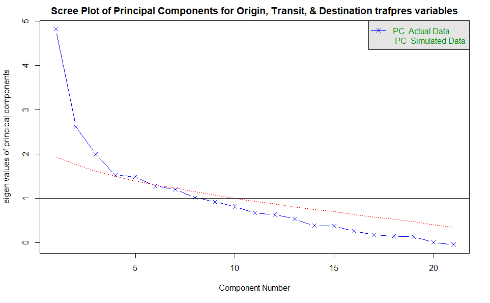

```
Matrix was not positive definite, smoothing was done
```

```
Loadings:
                   RC1    RC3    RC5    RC2    RC4    RC6
O_labor             0.418  0.727                0.101
O_sex                      0.856  0.232         0.101  0.128
T_labor             0.380                       0.838
T_sex              -0.108  0.197  0.202         0.864
D_labor             0.703 -0.379  0.236 -0.135  0.140  0.113
D_sex               0.242 -0.294  0.616 -0.114  0.369
labor_men           0.806  0.295        -0.152  0.105
labor_women         0.831  0.354
sex_women           0.245  0.422  0.674 -0.128  0.292
sex_men             0.141  0.104                0.141
fam_trafficker                           0.164         0.665
teac_trafficker                          0.949 -0.125
dipl_trafficker     0.105 -0.131  0.108  0.135 -0.222  0.121
brok_trafficker     0.193  0.339                       0.800
empl_trafficker     0.314         0.128 -0.113  0.173  0.364
bus_trafficker      0.546 -0.149  0.355  0.337
crim_trafficker                   0.142                0.606
militia_trafficker         0.167 -0.153                0.125
govt_trafficker     0.143  0.311  0.357
rel_trafficker                           0.894
pimp_trafficker            0.199  0.882                0.159
                   RC7    RC8
O_labor             0.371
O_sex
T_labor             0.135
T_sex
D_labor                    0.183
D_sex              -0.219  0.307
labor_men           0.106  0.129
labor_women
sex_women          -0.285  0.141
sex_men                    0.826
fam_trafficker      0.397 -0.113
teac_trafficker
dipl_trafficker     0.180  0.581
brok_trafficker    -0.190
empl_trafficker     0.316  0.206
bus_trafficker      0.445
crim_trafficker            0.479
militia_trafficker  0.665  0.193
govt_trafficker     0.518  0.139
rel_trafficker      0.103  0.216
pimp_trafficker     0.176

                 RC1   RC3   RC5   RC2   RC4   RC6   RC7   RC8
SS loadings    2.795 2.271 2.116 1.977 1.865 1.723 1.615 1.589
Proportion Var 0.133 0.108 0.101 0.094 0.089 0.082 0.077 0.076
Cumulative Var 0.133 0.241 0.342 0.436 0.525 0.607 0.684 0.760
```

```r
new_HTCdata <-
HTCdata %>%
  mutate(business_and_labor_index = D_labor * .23 + labor_men * .31 + labor_women * .32 + bus_trafficker * .14,
       origin_index = O_labor * .42 + O_sex * .58,
       pimps_sex_trafficking_index = D_sex * .24 + sex_women * .28 + pimp_trafficker * .48,
       religious_teacher_trafficker_index = rel_trafficker * .47 + teac_trafficker * .53,
       transit_index = T_labor * .48 + T_sex * .52,
       broker_criminal_trafficker_index = crim_trafficker * .26 + fam_trafficker * .3 + brok_trafficker * .44,
       govt_militia_trafficker_index = militia_trafficker * .62 + govt_trafficker * .38,
       diplomat_sex_w_men_index = sex_men * .67 + dipl_trafficker * .33)
```

## Principal Components Analysis (PCA) update - March 2018

### Traffickers, targets, and types

```r
trafpresCor_pca_mar18 <- qgraph::cor_auto(HTCdata_v2 %>% select(vars_pca_mar18),
                                          detectOrdinal = TRUE, forcePD = FALSE)
```

```
Note: Using an external vector in selections is ambiguous.
i Use `all_of(vars_pca_mar18)` instead of `vars_pca_mar18` to silence this message.
i See <https://tidyselect.r-lib.org/reference/faq-external-vector.html>.
Variables detected as ordinal: O_labor; O_sex; T_labor; T_sex; D_labor; D_sex; labor_men; labor_women; sex_women; fam_trafficker; teac_trafficker; empl_trafficker; bus_trafficker; crim_trafficker; militia_trafficker; govt_trafficker; pimp_trafficker
```

[output not shown]

```r
autoplot(prcomp(trafpresCor_pca_mar18), loadings = TRUE, loadings.label = TRUE) +
  my.theme
```

[output not shown]

```r
trafpresCor_pca_mar18_2 <- qgraph::cor_auto(HTCdata_v2 %>% select(vars_pca_mar18_2),
                                          detectOrdinal = TRUE, forcePD = FALSE)
```

```
Note: Using an external vector in selections is ambiguous.
i Use `all_of(vars_pca_mar18_2)` instead of `vars_pca_mar18_2` to silence this message.
i See <https://tidyselect.r-lib.org/reference/faq-external-vector.html>.
Variables detected as ordinal: O_labor; O_sex; T_labor; T_sex; D_labor; D_sex; labor_men; labor_women; sex_women; fam_trafficker; teac_trafficker; bus_trafficker; crim_trafficker; militia_trafficker; govt_trafficker; pimp_trafficker
```

[output not shown]

```
Parallel analysis suggests that the number of factors =  NA  and the number of components =  3
```

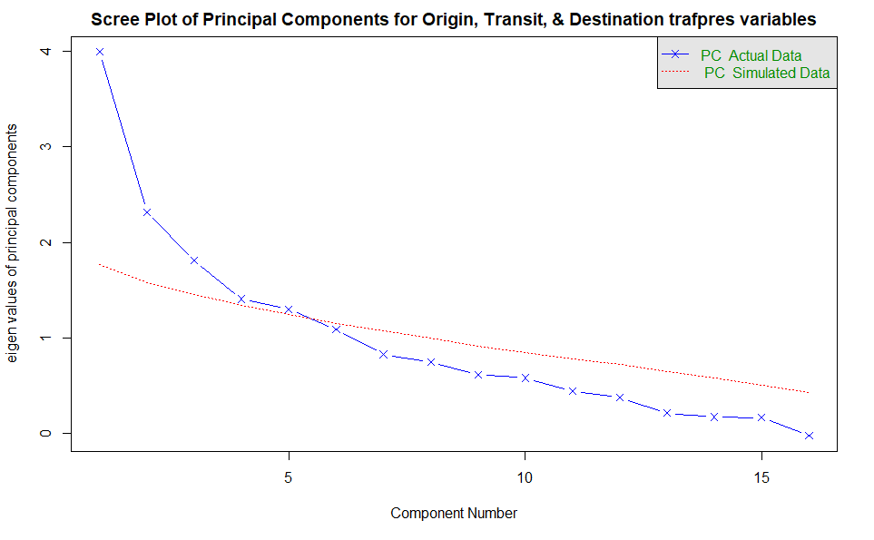

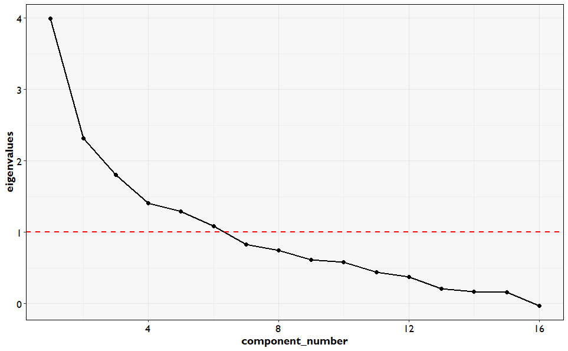

```
Principal Components Analysis
Call: principal(r = trafpresCor_pca_mar18_2, nfactors = 6, residuals = TRUE,
    rotate = "varimax", scores = TRUE)
Standardized loadings (pattern matrix) based upon correlation matrix
```

|  | RC1 | RC4 | RC2 | RC5 | RC3 | RC6 | h2 | u2 | com |
| --- | --- | --- | --- | --- | --- | --- | --- | --- | --- |
| O_labor | 0.72 | 0.17 | -0.48 | 0.20 | 0.20 | 0.05 | 0.8690851 | 0.1309149 | 2.301314 |
| O_sex | 0.39 | 0.51 | -0.59 | 0.19 | 0.04 | 0.06 | 0.7987447 | 0.2012553 | 3.008959 |
| T_labor | 0.27 | -0.12 | 0.21 | 0.85 | -0.03 | 0.11 | 0.8750029 | 0.1249971 | 1.414646 |
| T_sex | 0.02 | 0.16 | -0.09 | 0.90 | 0.01 | -0.18 | 0.8745622 | 0.1254378 | 1.171663 |
| D_labor | 0.35 | 0.11 | 0.81 | 0.08 | 0.03 | -0.03 | 0.7931769 | 0.2068231 | 1.434342 |
| D_sex | -0.07 | 0.54 | 0.64 | 0.29 | -0.12 | -0.08 | 0.8049578 | 0.1950422 | 2.521044 |
| labor_men | 0.89 | 0.11 | 0.16 | 0.13 | 0.11 | -0.07 | 0.8598365 | 0.1401635 | 1.191469 |
| labor_women | 0.85 | 0.19 | 0.14 | 0.03 | -0.12 | 0.09 | 0.7954104 | 0.2045896 | 1.231117 |
| sex_women | 0.31 | 0.82 | 0.08 | 0.25 | -0.17 | -0.12 | 0.8828982 | 0.1171018 | 1.647752 |
| fam_trafficker | -0.01 | -0.18 | -0.03 | -0.08 | 0.74 | 0.03 | 0.5933370 | 0.4066630 | 1.140666 |

[output cut: 6 more lines]

```
                       RC1  RC4  RC2  RC5  RC3  RC6
SS loadings           2.65 2.27 2.01 1.85 1.76 1.36
Proportion Var        0.17 0.14 0.13 0.12 0.11 0.09
Cumulative Var        0.17 0.31 0.43 0.55 0.66 0.74
Proportion Explained  0.22 0.19 0.17 0.16 0.15 0.11
Cumulative Proportion 0.22 0.41 0.58 0.74 0.89 1.00

Mean item complexity =  1.8
Test of the hypothesis that 6 components are sufficient.

The root mean square of the residuals (RMSR) is  0.07

Fit based upon off diagonal values = 0.93
```

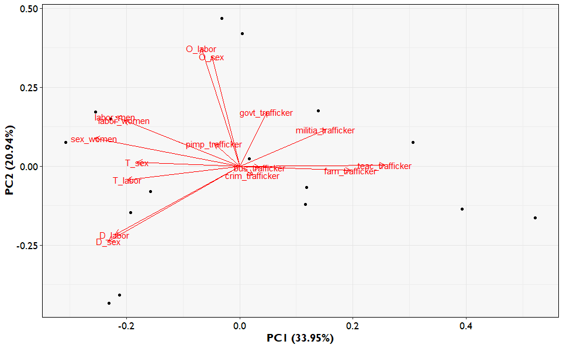

## Sum coding and rank of sum coding

```r
#identifying and removing multiple CY observations
mult_CY_obs <- HTCdata_v2 %>%
  group_by(country, year) %>%
  summarise(count = n()) %>%
  arrange(desc(count)) %>%
  mutate(country_year = paste(country, year, sep="_")) %>%
  filter(count > 1) %>%
  ungroup() %>%
  select(country_year)
```

```r
HTCdata_index_mar18 <- HTCdata_v2 %>%
  mutate(country_year = paste(country, year, sep="_")) %>%
  filter(!country_year %in% mult_CY_obs$country_year) %>%
  #select(index_coeff_simple_mar18$variable) %>%
  gather(variable, value, 3:42) %>%
  full_join(x=.,
            y=index_coeff_mar18,
            by='variable') %>%
  mutate(index_value_stage1 = value * coeff) %>%
  group_by(country, year, country_year, component) %>%
  summarise(sub_index = sum(index_value_stage1, na.rm = TRUE)) %>%
  full_join(x=.,
            y=ss_loadings_mar18,
            by='component') %>%
  filter(!is.na(component)) %>%
  mutate(HTI_subindex_score = sub_index * value,
         sub_index_name = ifelse(component == 'RC1', 'Internal Forced Child Labor Trafficking (PC1)',
                          ifelse(component == 'RC2', 'General Labor Trafficking (PC2)',
                          ifelse(component == 'RC3', 'Countries of Origin for Child Trafficking (PC3)',
                          ifelse(component == 'RC5', 'Internal Sex Trafficking (PC5)',
                          ifelse(component == 'RC6', 'Domestic Servitude Trafficking (PC6)',
                          ifelse(component == 'RC7', 'Forced Marriage Trafficking (PC7)',
                          ifelse(component == 'RC8', 'Transit Countries for Sex & Labor Trafficking (PC8)',
                          ifelse(component == 'RC9', 'Militia-related Trafficking (PC9)',
                          ifelse(component == 'RC10', 'Destination of Child Trafficking (PC10)',
                                                      'Destination of Child Sex Tourism Trafficking (PC11)')))))))))) %>%
  ungroup()
```

[output not shown]

```r
pca_index_analysis_of_rank <- HTCdata_v2 %>%
  mutate(country_year = paste(country, year, sep="_")) %>%
  filter(!country_year %in% mult_CY_obs$country_year) %>%
  filter(year == 2015) %>%
  select(-country_year) %>%
  gather(var, val, 3:42) %>%
  group_by(country, year) %>%
  summarise(sum_val = sum(val, na.rm=TRUE)) %>%
  arrange(desc(sum_val)) %>%
  ungroup() %>%
  #min_rank() and dense_rank() should both be explored
  #min_rank() allows for ties but gives gaps between ranking
  #dense_rank() allows for ties but does not give gaps between rankings
  mutate(rank_sum = min_rank(desc(sum_val))) %>%
  left_join(x=.,
            y=final_df,
            by=c('country' = 'country', 'year' = 'year')) %>%
  mutate(rank_HTI_total_index = min_rank(desc(HTI_total_index))) %>%
  mutate(rank_difference = rank_HTI_total_index - rank_sum) %>%
  mutate(`Absolute value of rank difference` = abs(rank_difference),
         `Valence of rank difference` = ifelse(rank_difference >0, 'Positive',
                                        ifelse(rank_difference <0, 'Negative', 'Zero')))
```

[output not shown]

```r
pca_index_analysis_of_rank %>%
  ggplot(.,
         aes(x=rank_sum,
                 y=rank_HTI_total_index)) +
  geom_point() +
  geom_smooth(method='lm') +
  ggtitle('Correlation between rank of HTCPI and sum of HTI coding') +
  my.theme
```

[output not shown]

```r
pca_index_analysis_of_rank %>%
  ggplot(.,
         aes(x=sum_val,
                 y=HTI_total_index)) +
  geom_point() +
  geom_smooth(method='lm') +
  ggtitle('Correlation between HTCPI and sum of HTI coding') +
  my.theme
```

[output not shown]

```r
final_df_map_ranks <- pca_index_analysis_of_rank %>%
  mutate(country = recode(country, 'Antigua and Barbuda' = 'Antigua',
                          'Brunei Darussalam' = 'Brunei',
                          "Côte d'Ivoire" = 'Ivory Coast',
                          'Congo, the Democratic Republic of the' = 'Democratic Republic of the Congo',
                          'Congo' = 'Republic of Congo',
                          'Cabo Verde' = 'Cape Verde',
                          'Curaçao' = 'Curacao',
                          'Micronesia, Federated States of' = 'Micronesia',
                          'United Kingdom' = 'UK',
                          'Iran, Islamic Republic of' = 'Iran',
                          'Korea, Republic of' = 'South Korea',
                          "Lao People's Democratic Republic" = 'Laos',
                          'Moldova, Republic of' = 'Moldova',
                          'Macedonia, the former Yugoslav Republic of' = 'Macedonia',
                          "Korea, Democratic People's Republic of" = 'North Korea',
                          'Syrian Arab Republic' = 'Syria',
                          'Taiwan, Province of China' = 'Taiwan',
                          'Tanzania, United Republic of' = 'Tanzania',
                          'United States of America' = 'USA',
                          'Venezuela, Bolivarian Republic of' = 'Venezuela',
                          'Viet Nam' = 'Vietnam',
                          'Russian Federation' = 'Russia'))

joined.world.map_ranks_comparison <-left_join(x=map.world,
                             y=final_df_map_ranks,
                             by=c('region' = 'country'))

joined.world.map_ranks_comparison %>%
  ggplot(.) +
  geom_polygon(aes(x = long, y = lat, group = group, fill = rank_difference), color="gray60") +
  scale_fill_gradient2(low = "red", high = "blue", mid = "white") +
  ggtitle('Map of Difference between rank of HTCPI less rank of sum of coding',
          subtitle = '2015 estimates') +
  #labs(caption = 'Using 2014 value if 2015 is NA') +
  map.theme +
  theme(plot.title = element_text(size=23))
```

[output not shown]

```r
GGally::ggcorr(pca_index_analysis_of_rank %>% select(3:16),
               hjust=1.1,
               layout.exp=4,
               size=3,
               label_alpha=.3,
               label = TRUE,
               label_round = 2) +
  ggtitle('Correlation matrix of ranks in sum coding vs. HTCPI') +
  theme(plot.title = element_text(hjust = .5, face="bold", size=22),
        text = element_text(family = "Gill Sans MT"))
```

[output not shown]

## Fit all vars for sub-indices and total HTI

```r
#Build polychoric correlation matrix
#ALL VARS

trafpresCor_pca_mar18_3 <- qgraph::cor_auto(HTCdata_v2 %>% select(3:42),
                                          detectOrdinal = TRUE, forcePD = FALSE)
```

```r
GGally::ggcorr(trafpresCor_pca_mar18_3, hjust=1.1, layout.exp=4, size=2, label_alpha=.3) +
  theme(text = element_text(family = "Gill Sans MT"))
```

[output not shown]

```r
pca_scree_vals <- data.frame(PCAscree_mar18_3$pc.values) %>%
  rename(eigenvalues = PCAscree_mar18_3.pc.values) %>%
  mutate(component_number = seq.int(1, 40, 1))

pca_scree_vals %>%
  ggplot(., aes(x=component_number,
                y=eigenvalues)) +
  geom_point(size=2) +
  geom_line(size=1) +
  ggtitle('Scree plot of eigenvalues of principal components',
          subtitle = 'Total Human Trafficking Principal Component Index dataset') +
  geom_hline(yintercept = 1, linetype = 'dashed', lwd=1, color='red') +
  my.theme
```

[output not shown]

## Index building

```r
index_coeff_mar18 <- readxl::read_xlsx('index_building_mar18.xlsx', sheet = 'coeff') %>%
  gather(component, coeff, 2:12) %>%
  filter(!is.na(coeff),
         component != 'RC4')

ss_loadings_mar18 <- readxl::read_xlsx('index_building_mar18.xlsx', sheet = 'ss_loadings') %>%
  gather(component, value, 2:12) %>%
  filter(var == 'SS loadings',
         component != 'RC4')

index_coeff_simple_mar18 <- readxl::read_xlsx('index_building_mar18.xlsx', sheet = 'coeff_simple')
```

```r
#what are the NA values in the HTI index?
#HTCdata_index_mar18 %>%
 # filter(country == 'Poland')

HTCdata %>%
  filter(country == 'South Africa')

#countries with NA are those with multiple CY observations
#do we need to treat those differently?
```

```r
#what's going on with Japan in 2008?
HTCdata_index_mar18 %>%
  ungroup() %>%
  filter(country_year == 'Japan_2008') %>%
  select(3, 8:9)
```

```r
#is there a child militia mention for Japan in 2008?
HTCdata_v2 %>%
  filter(country == 'Japan',
         year == '2008') %>%
  select(country, year, contains('militi', ignore.case = TRUE))
```

### Plotting

```r
autoplot(prcomp(trafpresCor_pca_mar18_3), loadings = TRUE, loadings.label = TRUE) +
  ggtitle('PCA plot of eigenvectors',
          subtitle = 'Human Trafficking Principal Component Index creation') +
  my.theme
```

[output not shown]

```r
test <- HTCdata_totalindex_mar18 %>%
  spread(year, HTI_total_index)
```

```r
HTI_var <- 'HTI_total_index'
col_name <- as.name(HTI_var)


final_df_to_map <- final_df %>%
  ungroup() %>%
    mutate(country = ifelse(country == 'Antigua and Barbuda', 'Antigua',
                   ifelse(country == 'Brunei Darussalam', 'Brunei',
                   ifelse(country == "Côte d'Ivoire", 'Ivory Coast',
                   ifelse(country == 'Congo, the Democratic Republic of the', 'Democratic Republic of the Congo',
                   ifelse(country == 'Congo', 'Republic of Congo',
                   ifelse(country == 'Cabo Verde', 'Cape Verde',
                   ifelse(country == 'Curaçao', 'Curacao',
                   ifelse(country == 'Micronesia, Federated States of', 'Micronesia',
                   ifelse(country == 'United Kingdom', 'UK',
                   ifelse(country == 'Iran, Islamic Republic of', 'Iran',
                   ifelse(country == 'Korea, Republic of', 'South Korea',
                   ifelse(country == "Lao People's Democratic Republic", 'Laos',
                   ifelse(country == 'Moldova, Republic of', 'Moldova',
                   ifelse(country == 'Macedonia, the former Yugoslav Republic of', 'Macedonia',
                   ifelse(country == "Korea, Democratic People's Republic of", 'North Korea',
                   ifelse(country == 'Syrian Arab Republic', 'Syria',
                   ifelse(country == 'Taiwan, Province of China', 'Taiwan',
                   ifelse(country == 'Tanzania, United Republic of', 'Tanzania',
                   ifelse(country == 'United States of America', 'USA',
                   ifelse(country == 'Venezuela, Bolivarian Republic of', 'Venezuela',
                   ifelse(country == 'Viet Nam', 'Vietnam',
                   ifelse(country == 'Russian Federation', 'Russia', as.character(country)))))))))))))))))))))))) %>%
  select_(1, 2, col_name) %>%
  filter(year == 2014 |
         year == 2015) %>%
  spread(year, 3) %>%
  mutate(HTI_var = ifelse(is.na(`2015`), `2014`, `2015`))

joined.world.map_2 <-left_join(x=map.world,
                             y=final_df_to_map,
                             by=c('region' = 'country'))

joined.world.map_2 %>%
  ggplot(.) +
  geom_polygon(aes(x = long, y = lat, group = group, fill = HTI_var)) +
  scale_fill_continuous(low = "#CCCCCC", high = "#e60000") +
  ggtitle('Map of HTI Composite Score',
          subtitle = '2015 estimates') +
  labs(caption = 'Using 2014 value if 2015 is NA') +
  map.theme
```

[output not shown]

```r
map.world <- map_data("world")


join_test <- anti_join(x=map.world,
          y=final_df_2,
          by=c('region' = 'country')) %>%
  select(region) %>%
  distinct()

final_df_2 <- final_df %>%
  ungroup() %>%
  select(1:3) %>%
  spread(year, HTI_total_index) %>%
  mutate(HTI_total_index = ifelse(is.na(`2015`), `2014`, `2015`)) %>%
  select(1, 5) %>%
  mutate(country = ifelse(country == 'Antigua and Barbuda', 'Antigua',
                   ifelse(country == 'Brunei Darussalam', 'Brunei',
                   ifelse(country == "Côte d'Ivoire", 'Ivory Coast',
                   ifelse(country == 'Congo, the Democratic Republic of the', 'Democratic Republic of the Congo',
                   ifelse(country == 'Congo', 'Republic of Congo',
                   ifelse(country == 'Cabo Verde', 'Cape Verde',
                   ifelse(country == 'Curaçao', 'Curacao',
                   ifelse(country == 'Micronesia, Federated States of', 'Micronesia',
                   ifelse(country == 'United Kingdom', 'UK',
                   ifelse(country == 'Iran, Islamic Republic of', 'Iran',
                   ifelse(country == 'Korea, Republic of', 'South Korea',
                   ifelse(country == "Lao People's Democratic Republic", 'Laos',
                   ifelse(country == 'Moldova, Republic of', 'Moldova',
                   ifelse(country == 'Macedonia, the former Yugoslav Republic of', 'Macedonia',
                   ifelse(country == "Korea, Democratic People's Republic of", 'North Korea',
                   ifelse(country == 'Syrian Arab Republic', 'Syria',
                   ifelse(country == 'Taiwan, Province of China', 'Taiwan',
                   ifelse(country == 'Tanzania, United Republic of', 'Tanzania',
                   ifelse(country == 'United States of America', 'USA',
                   ifelse(country == 'Venezuela, Bolivarian Republic of', 'Venezuela',
                   ifelse(country == 'Viet Nam', 'Vietnam',
                   ifelse(country == 'Russian Federation', 'Russia', as.character(country))))))))))))))))))))))))

joined.world.map <-left_join(x=map.world,
                             y=final_df_2,
                             by=c('region' = 'country'))

joined.world.map %>%
  ggplot(.) +
  geom_polygon(aes(x = long, y = lat, group = group, fill = HTI_total_index), color="gray60") +
  scale_fill_continuous(low = "#CCCCCC", high = "#e60000") +
  ggtitle('Map of HTPCI Score',
          subtitle = '2015 estimates') +
  labs(caption = 'Using 2014 value if 2015 is NA') +
  map.theme



final_df_3 <- final_df %>%
  ungroup() %>%
  select(1:2, `Forced Marriage Trafficking`) %>%
  spread(year, `Forced Marriage Trafficking`) %>%
  mutate(`Forced Marriage Trafficking` = ifelse(is.na(`2015`), `2014`, `2015`)) %>%
  select(1, 5) %>%
  mutate(country = ifelse(country == 'Antigua and Barbuda', 'Antigua',
                   ifelse(country == 'Brunei Darussalam', 'Brunei',
                   ifelse(country == "Côte d'Ivoire", 'Ivory Coast',
                   ifelse(country == 'Congo, the Democratic Republic of the', 'Democratic Republic of the Congo',
                   ifelse(country == 'Congo', 'Republic of Congo',
                   ifelse(country == 'Cabo Verde', 'Cape Verde',
                   ifelse(country == 'Curaçao', 'Curacao',
                   ifelse(country == 'Micronesia, Federated States of', 'Micronesia',
                   ifelse(country == 'United Kingdom', 'UK',
                   ifelse(country == 'Iran, Islamic Republic of', 'Iran',
                   ifelse(country == 'Korea, Republic of', 'South Korea',
                   ifelse(country == "Lao People's Democratic Republic", 'Laos',
                   ifelse(country == 'Moldova, Republic of', 'Moldova',
                   ifelse(country == 'Macedonia, the former Yugoslav Republic of', 'Macedonia',
                   ifelse(country == "Korea, Democratic People's Republic of", 'North Korea',
                   ifelse(country == 'Syrian Arab Republic', 'Syria',
                   ifelse(country == 'Taiwan, Province of China', 'Taiwan',
                   ifelse(country == 'Tanzania, United Republic of', 'Tanzania',
                   ifelse(country == 'United States of America', 'USA',
                   ifelse(country == 'Venezuela, Bolivarian Republic of', 'Venezuela',
                   ifelse(country == 'Viet Nam', 'Vietnam',
                   ifelse(country == 'Russian Federation', 'Russia', as.character(country))))))))))))))))))))))))


joined.world.map2 <-left_join(x=map.world,
                             y=final_df_3,
                             by=c('region' = 'country'))

joined.world.map2 %>%
  ggplot(.) +
  geom_polygon(aes(x = long, y = lat, group = group, fill = `Forced Marriage Trafficking`), color="gray60") +
  scale_fill_continuous(low = "#CCCCCC", high = "#e60000") +
  ggtitle('Map of Forced Marriage Index Score',
          subtitle = '2015 estimates') +
  labs(caption = 'Using 2014 value if 2015 is NA') +
  map.theme


final_df_4 <- final_df %>%
  ungroup() %>%
  select(1:2, `Pimp Trafficker & Internal Sex Trafficking`) %>%
  spread(year, `Pimp Trafficker & Internal Sex Trafficking`) %>%
  mutate(`Pimp Trafficker & Internal Sex Trafficking` = ifelse(is.na(`2015`), `2014`, `2015`)) %>%
  select(1, 5) %>%
  mutate(country = ifelse(country == 'Antigua and Barbuda', 'Antigua',
                   ifelse(country == 'Brunei Darussalam', 'Brunei',
                   ifelse(country == "Côte d'Ivoire", 'Ivory Coast',
                   ifelse(country == 'Congo, the Democratic Republic of the', 'Democratic Republic of the Congo',
                   ifelse(country == 'Congo', 'Republic of Congo',
                   ifelse(country == 'Cabo Verde', 'Cape Verde',
                   ifelse(country == 'Curaçao', 'Curacao',
                   ifelse(country == 'Micronesia, Federated States of', 'Micronesia',
                   ifelse(country == 'United Kingdom', 'UK',
                   ifelse(country == 'Iran, Islamic Republic of', 'Iran',
                   ifelse(country == 'Korea, Republic of', 'South Korea',
                   ifelse(country == "Lao People's Democratic Republic", 'Laos',
                   ifelse(country == 'Moldova, Republic of', 'Moldova',
                   ifelse(country == 'Macedonia, the former Yugoslav Republic of', 'Macedonia',
                   ifelse(country == "Korea, Democratic People's Republic of", 'North Korea',
                   ifelse(country == 'Syrian Arab Republic', 'Syria',
                   ifelse(country == 'Taiwan, Province of China', 'Taiwan',
                   ifelse(country == 'Tanzania, United Republic of', 'Tanzania',
                   ifelse(country == 'United States of America', 'USA',
                   ifelse(country == 'Venezuela, Bolivarian Republic of', 'Venezuela',
                   ifelse(country == 'Viet Nam', 'Vietnam',
                   ifelse(country == 'Russian Federation', 'Russia', as.character(country))))))))))))))))))))))))
```

[output not shown]

```r
joined.world.map3 <-left_join(x=map.world,
                             y=final_df_4,
                             by=c('region' = 'country'))

joined.world.map3 %>%
  ggplot(.) +
  geom_polygon(aes(x = long, y = lat, group = group, fill = `Pimp Trafficker & Internal Sex Trafficking`), color="gray60") +
  scale_fill_continuous(low = "#CCCCCC", high = "#e60000") +
  ggtitle('Map of Pimp Trafficker & Internal Sex Trafficking Score',
          subtitle = '2015 estimates') +
  labs(caption = 'Using 2014 value if 2015 is NA') +
  map.theme +
  theme(plot.title = element_text(size=40))


final_df_5 <- final_df %>%
  ungroup() %>%
  select(1:2, `Destination of Child Trafficking`) %>%
  spread(year, `Destination of Child Trafficking`) %>%
  mutate(`Destination of Child Trafficking` = ifelse(is.na(`2015`), `2014`, `2015`)) %>%
  select(1, 5) %>%
  mutate(country = ifelse(country == 'Antigua and Barbuda', 'Antigua',
                   ifelse(country == 'Brunei Darussalam', 'Brunei',
                   ifelse(country == "Côte d'Ivoire", 'Ivory Coast',
                   ifelse(country == 'Congo, the Democratic Republic of the', 'Democratic Republic of the Congo',
                   ifelse(country == 'Congo', 'Republic of Congo',
                   ifelse(country == 'Cabo Verde', 'Cape Verde',
                   ifelse(country == 'Curaçao', 'Curacao',
                   ifelse(country == 'Micronesia, Federated States of', 'Micronesia',
                   ifelse(country == 'United Kingdom', 'UK',
                   ifelse(country == 'Iran, Islamic Republic of', 'Iran',
                   ifelse(country == 'Korea, Republic of', 'South Korea',
                   ifelse(country == "Lao People's Democratic Republic", 'Laos',
                   ifelse(country == 'Moldova, Republic of', 'Moldova',
                   ifelse(country == 'Macedonia, the former Yugoslav Republic of', 'Macedonia',
                   ifelse(country == "Korea, Democratic People's Republic of", 'North Korea',
                   ifelse(country == 'Syrian Arab Republic', 'Syria',
                   ifelse(country == 'Taiwan, Province of China', 'Taiwan',
                   ifelse(country == 'Tanzania, United Republic of', 'Tanzania',
                   ifelse(country == 'United States of America', 'USA',
                   ifelse(country == 'Venezuela, Bolivarian Republic of', 'Venezuela',
                   ifelse(country == 'Viet Nam', 'Vietnam',
                   ifelse(country == 'Russian Federation', 'Russia', as.character(country))))))))))))))))))))))))


joined.world.map4 <-left_join(x=map.world,
                             y=final_df_5,
                             by=c('region' = 'country'))

joined.world.map4 %>%
  ggplot(.) +
  geom_polygon(aes(x = long, y = lat, group = group, fill = `Destination of Child Trafficking`), color="gray60") +
  scale_fill_continuous(low = "#CCCCCC", high = "#e60000") +
  ggtitle('Map of Destination of Child Trafficking Score',
          subtitle = '2015 estimates') +
  labs(caption = 'Using 2014 value if 2015 is NA') +
  map.theme +
  theme(plot.title = element_text(size=45))

final_df_6 <- final_df %>%
  ungroup() %>%
  select(1:2, `Origin of Child Trafficking`) %>%
  spread(year, `Origin of Child Trafficking`) %>%
  mutate(`Origin of Child Trafficking` = ifelse(is.na(`2015`), `2014`, `2015`)) %>%
  select(1, 5) %>%
  mutate(country = ifelse(country == 'Antigua and Barbuda', 'Antigua',
                   ifelse(country == 'Brunei Darussalam', 'Brunei',
                   ifelse(country == "Côte d'Ivoire", 'Ivory Coast',
                   ifelse(country == 'Congo, the Democratic Republic of the', 'Democratic Republic of the Congo',
                   ifelse(country == 'Congo', 'Republic of Congo',
                   ifelse(country == 'Cabo Verde', 'Cape Verde',
                   ifelse(country == 'Curaçao', 'Curacao',
                   ifelse(country == 'Micronesia, Federated States of', 'Micronesia',
                   ifelse(country == 'United Kingdom', 'UK',
                   ifelse(country == 'Iran, Islamic Republic of', 'Iran',
                   ifelse(country == 'Korea, Republic of', 'South Korea',
                   ifelse(country == "Lao People's Democratic Republic", 'Laos',
                   ifelse(country == 'Moldova, Republic of', 'Moldova',
                   ifelse(country == 'Macedonia, the former Yugoslav Republic of', 'Macedonia',
                   ifelse(country == "Korea, Democratic People's Republic of", 'North Korea',
                   ifelse(country == 'Syrian Arab Republic', 'Syria',
                   ifelse(country == 'Taiwan, Province of China', 'Taiwan',
                   ifelse(country == 'Tanzania, United Republic of', 'Tanzania',
                   ifelse(country == 'United States of America', 'USA',
                   ifelse(country == 'Venezuela, Bolivarian Republic of', 'Venezuela',
                   ifelse(country == 'Viet Nam', 'Vietnam',
                   ifelse(country == 'Russian Federation', 'Russia', as.character(country))))))))))))))))))))))))


joined.world.map5 <-left_join(x=map.world,
                             y=final_df_6,
                             by=c('region' = 'country'))

joined.world.map5 %>%
  ggplot(.) +
  geom_polygon(aes(x = long, y = lat, group = group, fill = `Origin of Child Trafficking`), color="gray60") +
  scale_fill_continuous(low = "#CCCCCC", high = "#e60000") +
  ggtitle('Map of Origin of Child Trafficking Score',
          subtitle = '2015 estimates') +
  labs(caption = 'Using 2014 value if 2015 is NA') +
  map.theme


final_df_7 <- final_df %>%
  ungroup() %>%
  select(1:2, `Labor Trafficking`) %>%
  spread(year, `Labor Trafficking`) %>%
  mutate(`Labor Trafficking` = ifelse(is.na(`2015`), `2014`, `2015`)) %>%
  select(1, 5) %>%
  mutate(country = ifelse(country == 'Antigua and Barbuda', 'Antigua',
                   ifelse(country == 'Brunei Darussalam', 'Brunei',
                   ifelse(country == "Côte d'Ivoire", 'Ivory Coast',
                   ifelse(country == 'Congo, the Democratic Republic of the', 'Democratic Republic of the Congo',
                   ifelse(country == 'Congo', 'Republic of Congo',
                   ifelse(country == 'Cabo Verde', 'Cape Verde',
                   ifelse(country == 'Curaçao', 'Curacao',
                   ifelse(country == 'Micronesia, Federated States of', 'Micronesia',
                   ifelse(country == 'United Kingdom', 'UK',
                   ifelse(country == 'Iran, Islamic Republic of', 'Iran',
                   ifelse(country == 'Korea, Republic of', 'South Korea',
                   ifelse(country == "Lao People's Democratic Republic", 'Laos',
                   ifelse(country == 'Moldova, Republic of', 'Moldova',
                   ifelse(country == 'Macedonia, the former Yugoslav Republic of', 'Macedonia',
                   ifelse(country == "Korea, Democratic People's Republic of", 'North Korea',
                   ifelse(country == 'Syrian Arab Republic', 'Syria',
                   ifelse(country == 'Taiwan, Province of China', 'Taiwan',
                   ifelse(country == 'Tanzania, United Republic of', 'Tanzania',
                   ifelse(country == 'United States of America', 'USA',
                   ifelse(country == 'Venezuela, Bolivarian Republic of', 'Venezuela',
                   ifelse(country == 'Viet Nam', 'Vietnam',
                   ifelse(country == 'Russian Federation', 'Russia', as.character(country))))))))))))))))))))))))
```

[output not shown]

```r
joined.world.map6 <-left_join(x=map.world,
                             y=final_df_7,
                             by=c('region' = 'country'))

joined.world.map6 %>%
  ggplot(.) +
  geom_polygon(aes(x = long, y = lat, group = group, fill = `Labor Trafficking`), color="gray60") +
  scale_fill_continuous(low = "#CCCCCC", high = "#e60000") +
  ggtitle('Map of Labor Trafficking Score',
          subtitle = '2015 estimates') +
  labs(caption = 'Using 2014 value if 2015 is NA') +
  map.theme


final_df_8 <- final_df %>%
  ungroup() %>%
  select(1:2, `Child Domestic Servitude / Community / Non-Sexual`) %>%
  spread(year, `Child Domestic Servitude / Community / Non-Sexual`) %>%
  mutate(`Child Domestic Servitude / Community / Non-Sexual` = ifelse(is.na(`2015`), `2014`, `2015`)) %>%
  select(1, 5) %>%
  mutate(country = ifelse(country == 'Antigua and Barbuda', 'Antigua',
                   ifelse(country == 'Brunei Darussalam', 'Brunei',
                   ifelse(country == "Côte d'Ivoire", 'Ivory Coast',
                   ifelse(country == 'Congo, the Democratic Republic of the', 'Democratic Republic of the Congo',
                   ifelse(country == 'Congo', 'Republic of Congo',
                   ifelse(country == 'Cabo Verde', 'Cape Verde',
                   ifelse(country == 'Curaçao', 'Curacao',
                   ifelse(country == 'Micronesia, Federated States of', 'Micronesia',
                   ifelse(country == 'United Kingdom', 'UK',
                   ifelse(country == 'Iran, Islamic Republic of', 'Iran',
                   ifelse(country == 'Korea, Republic of', 'South Korea',
                   ifelse(country == "Lao People's Democratic Republic", 'Laos',
                   ifelse(country == 'Moldova, Republic of', 'Moldova',
                   ifelse(country == 'Macedonia, the former Yugoslav Republic of', 'Macedonia',
                   ifelse(country == "Korea, Democratic People's Republic of", 'North Korea',
                   ifelse(country == 'Syrian Arab Republic', 'Syria',
                   ifelse(country == 'Taiwan, Province of China', 'Taiwan',
                   ifelse(country == 'Tanzania, United Republic of', 'Tanzania',
                   ifelse(country == 'United States of America', 'USA',
                   ifelse(country == 'Venezuela, Bolivarian Republic of', 'Venezuela',
                   ifelse(country == 'Viet Nam', 'Vietnam',
                   ifelse(country == 'Russian Federation', 'Russia', as.character(country))))))))))))))))))))))))

joined.world.map7 <-left_join(x=map.world,
                             y=final_df_8,
                             by=c('region' = 'country'))

joined.world.map7 %>%
  ggplot(.) +
  geom_polygon(aes(x = long, y = lat, group = group, fill = `Child Domestic Servitude / Community / Non-Sexual`), color="gray60") +
  scale_fill_continuous(low = "#CCCCCC", high = "#e60000") +
  ggtitle('Map of Community Traffickers / Child Domestic Servitude Score',
          subtitle = '2015 estimates') +
  labs(caption = 'Using 2014 value if 2015 is NA') +
  map.theme +
  theme(plot.title = element_text(size=30))


final_df_9 <- final_df %>%
  ungroup() %>%
  select(1:2, `Criminal & Family Trafficker / Destination Child Sex Tourism`) %>%
  spread(year, `Criminal & Family Trafficker / Destination Child Sex Tourism`) %>%
  mutate(`Criminal & Family Trafficker / Destination Child Sex Tourism` = ifelse(is.na(`2015`), `2014`, `2015`)) %>%
  select(1, 5) %>%
  mutate(country = ifelse(country == 'Antigua and Barbuda', 'Antigua',
                   ifelse(country == 'Brunei Darussalam', 'Brunei',
                   ifelse(country == "Côte d'Ivoire", 'Ivory Coast',
                   ifelse(country == 'Congo, the Democratic Republic of the', 'Democratic Republic of the Congo',
                   ifelse(country == 'Congo', 'Republic of Congo',
                   ifelse(country == 'Cabo Verde', 'Cape Verde',
                   ifelse(country == 'Curaçao', 'Curacao',
                   ifelse(country == 'Micronesia, Federated States of', 'Micronesia',
                   ifelse(country == 'United Kingdom', 'UK',
                   ifelse(country == 'Iran, Islamic Republic of', 'Iran',
                   ifelse(country == 'Korea, Republic of', 'South Korea',
                   ifelse(country == "Lao People's Democratic Republic", 'Laos',
                   ifelse(country == 'Moldova, Republic of', 'Moldova',
                   ifelse(country == 'Macedonia, the former Yugoslav Republic of', 'Macedonia',
                   ifelse(country == "Korea, Democratic People's Republic of", 'North Korea',
                   ifelse(country == 'Syrian Arab Republic', 'Syria',
                   ifelse(country == 'Taiwan, Province of China', 'Taiwan',
                   ifelse(country == 'Tanzania, United Republic of', 'Tanzania',
                   ifelse(country == 'United States of America', 'USA',
                   ifelse(country == 'Venezuela, Bolivarian Republic of', 'Venezuela',
                   ifelse(country == 'Viet Nam', 'Vietnam',
                   ifelse(country == 'Russian Federation', 'Russia', as.character(country))))))))))))))))))))))))

joined.world.map8 <-left_join(x=map.world,
                             y=final_df_9,
                             by=c('region' = 'country'))

joined.world.map8 %>%
  ggplot(.) +
  geom_polygon(aes(x = long, y = lat, group = group, fill = `Criminal & Family Trafficker / Destination Child Sex Tourism`), color="gray60") +
  scale_fill_continuous(low = "#CCCCCC", high = "#e60000") +
  ggtitle('Map of Criminal & Family / Child Sex Tourism Score',
          subtitle = '2015 estimates') +
  labs(caption = 'Using 2014 value if 2015 is NA') +
  map.theme +
  theme(plot.title = element_text(size=40))

final_df_10 <- final_df %>%
  ungroup() %>%
  select(1:2, `Employer Trafficking & Dom Servitude / Debt Bondage`) %>%
  spread(year, `Employer Trafficking & Dom Servitude / Debt Bondage`) %>%
  mutate(`Employer Trafficking & Dom Servitude / Debt Bondage` = ifelse(is.na(`2015`), `2014`, `2015`)) %>%
  select(1, 5) %>%
  mutate(country = ifelse(country == 'Antigua and Barbuda', 'Antigua',
                   ifelse(country == 'Brunei Darussalam', 'Brunei',
                   ifelse(country == "Côte d'Ivoire", 'Ivory Coast',
                   ifelse(country == 'Congo, the Democratic Republic of the', 'Democratic Republic of the Congo',
                   ifelse(country == 'Congo', 'Republic of Congo',
                   ifelse(country == 'Cabo Verde', 'Cape Verde',
                   ifelse(country == 'Curaçao', 'Curacao',
                   ifelse(country == 'Micronesia, Federated States of', 'Micronesia',
                   ifelse(country == 'United Kingdom', 'UK',
                   ifelse(country == 'Iran, Islamic Republic of', 'Iran',
                   ifelse(country == 'Korea, Republic of', 'South Korea',
                   ifelse(country == "Lao People's Democratic Republic", 'Laos',
                   ifelse(country == 'Moldova, Republic of', 'Moldova',
                   ifelse(country == 'Macedonia, the former Yugoslav Republic of', 'Macedonia',
                   ifelse(country == "Korea, Democratic People's Republic of", 'North Korea',
                   ifelse(country == 'Syrian Arab Republic', 'Syria',
                   ifelse(country == 'Taiwan, Province of China', 'Taiwan',
                   ifelse(country == 'Tanzania, United Republic of', 'Tanzania',
                   ifelse(country == 'United States of America', 'USA',
                   ifelse(country == 'Venezuela, Bolivarian Republic of', 'Venezuela',
                   ifelse(country == 'Viet Nam', 'Vietnam',
                   ifelse(country == 'Russian Federation', 'Russia', as.character(country))))))))))))))))))))))))
```

[output not shown]

```r
joined.world.map9 <-left_join(x=map.world,
                             y=final_df_10,
                             by=c('region' = 'country'))

joined.world.map9 %>%
  ggplot(.) +
  geom_polygon(aes(x = long, y = lat, group = group, fill = `Employer Trafficking & Dom Servitude / Debt Bondage`), color="gray60") +
  scale_fill_continuous(low = "#CCCCCC", high = "#e60000") +
  ggtitle('Map of Employment Agency Trafficking & Domestic Servitude / Debt Bondage Score',
          subtitle = '2015 estimates') +
  labs(caption = 'Using 2014 value if 2015 is NA') +
  map.theme +
  theme(plot.title = element_text(size=26))


final_df_11 <- final_df %>%
  ungroup() %>%
  select(1:2, `Militia-related Trafficking`) %>%
  spread(year, `Militia-related Trafficking`) %>%
  mutate(`Militia-related Trafficking` = ifelse(is.na(`2015`), `2014`, `2015`)) %>%
  select(1, 5) %>%
  mutate(country = ifelse(country == 'Antigua and Barbuda', 'Antigua',
                   ifelse(country == 'Brunei Darussalam', 'Brunei',
                   ifelse(country == "Côte d'Ivoire", 'Ivory Coast',
                   ifelse(country == 'Congo, the Democratic Republic of the', 'Democratic Republic of the Congo',
                   ifelse(country == 'Congo', 'Republic of Congo',
                   ifelse(country == 'Cabo Verde', 'Cape Verde',
                   ifelse(country == 'Curaçao', 'Curacao',
                   ifelse(country == 'Micronesia, Federated States of', 'Micronesia',
                   ifelse(country == 'United Kingdom', 'UK',
                   ifelse(country == 'Iran, Islamic Republic of', 'Iran',
                   ifelse(country == 'Korea, Republic of', 'South Korea',
                   ifelse(country == "Lao People's Democratic Republic", 'Laos',
                   ifelse(country == 'Moldova, Republic of', 'Moldova',
                   ifelse(country == 'Macedonia, the former Yugoslav Republic of', 'Macedonia',
                   ifelse(country == "Korea, Democratic People's Republic of", 'North Korea',
                   ifelse(country == 'Syrian Arab Republic', 'Syria',
                   ifelse(country == 'Taiwan, Province of China', 'Taiwan',
                   ifelse(country == 'Tanzania, United Republic of', 'Tanzania',
                   ifelse(country == 'United States of America', 'USA',
                   ifelse(country == 'Venezuela, Bolivarian Republic of', 'Venezuela',
                   ifelse(country == 'Viet Nam', 'Vietnam',
                   ifelse(country == 'Russian Federation', 'Russia', as.character(country))))))))))))))))))))))))

joined.world.map10 <-left_join(x=map.world,
                             y=final_df_11,
                             by=c('region' = 'country'))

joined.world.map10 %>%
  ggplot(.) +
  geom_polygon(aes(x = long, y = lat, group = group, fill = `Militia-related Trafficking`), color="gray60") +
  scale_fill_continuous(low = "#CCCCCC", high = "#e60000") +
  ggtitle('Map of Militia-related Trafficking Score',
          subtitle = '2015 estimates') +
  labs(caption = 'Using 2014 value if 2015 is NA') +
  map.theme

final_df_12 <- final_df %>%
  ungroup() %>%
  select(1:2, `Transit for Sex & Labor Trafficking`) %>%
  spread(year, `Transit for Sex & Labor Trafficking`) %>%
  mutate(`Transit for Sex & Labor Trafficking` = ifelse(is.na(`2015`), `2014`, `2015`)) %>%
  select(1, 5) %>%
  mutate(country = ifelse(country == 'Antigua and Barbuda', 'Antigua',
                   ifelse(country == 'Brunei Darussalam', 'Brunei',
                   ifelse(country == "Côte d'Ivoire", 'Ivory Coast',
                   ifelse(country == 'Congo, the Democratic Republic of the', 'Democratic Republic of the Congo',
                   ifelse(country == 'Congo', 'Republic of Congo',
                   ifelse(country == 'Cabo Verde', 'Cape Verde',
                   ifelse(country == 'Curaçao', 'Curacao',
                   ifelse(country == 'Micronesia, Federated States of', 'Micronesia',
                   ifelse(country == 'United Kingdom', 'UK',
                   ifelse(country == 'Iran, Islamic Republic of', 'Iran',
                   ifelse(country == 'Korea, Republic of', 'South Korea',
                   ifelse(country == "Lao People's Democratic Republic", 'Laos',
                   ifelse(country == 'Moldova, Republic of', 'Moldova',
                   ifelse(country == 'Macedonia, the former Yugoslav Republic of', 'Macedonia',
                   ifelse(country == "Korea, Democratic People's Republic of", 'North Korea',
                   ifelse(country == 'Syrian Arab Republic', 'Syria',
                   ifelse(country == 'Taiwan, Province of China', 'Taiwan',
                   ifelse(country == 'Tanzania, United Republic of', 'Tanzania',
                   ifelse(country == 'United States of America', 'USA',
                   ifelse(country == 'Venezuela, Bolivarian Republic of', 'Venezuela',
                   ifelse(country == 'Viet Nam', 'Vietnam',
                   ifelse(country == 'Russian Federation', 'Russia', as.character(country))))))))))))))))))))))))

joined.world.map11 <-left_join(x=map.world,
                             y=final_df_12,
                             by=c('region' = 'country'))

joined.world.map11 %>%
  ggplot(.) +
  geom_polygon(aes(x = long, y = lat, group = group, fill = `Transit for Sex & Labor Trafficking`), color="gray60") +
  scale_fill_continuous(low = "#CCCCCC", high = "#e60000") +
  ggtitle('Map of Transit Country of Trafficking Score',
          subtitle = '2015 estimates') +
  labs(caption = 'Using 2014 value if 2015 is NA') +
  map.theme
```

[output not shown]

```r
library(rgdal)        # for readOGR(...)

world      <- readOGR(dsn=".",
                      layer="world_country_admin_boundary_shapefile_with_fips_codes")

countries <- world@data
countries <- cbind(id=rownames(countries),countries)
countries <- merge(countries,gtd.recent,
                   by.x="CNTRY_NAME", by.y="country_txt", all.x=T)
map.df <- fortify(world)
map.df <- merge(map.df,countries, by="id")
ggplot(map.df, aes(x=long,y=lat,group=group)) +
  geom_polygon(aes(fill=nkill))+
  geom_path(colour="grey50")+
  scale_fill_gradientn(name="Deaths",
                       colours=rev(brewer.pal(9,"Spectral")),
                       na.value="white")+
  coord_fixed()+labs(x="",y="")
```

[output not shown]

# CFA Testing - April 2017

```r
#specify model
test.cfa <- " origin =~ O_labor + O_childlabor + O_sex + O_childsex +
                        O_cstourism + O_domestic + O_begging
              transit =~ T_labor + T_childlabor + T_sex + T_childsex +
                          T_cstourism + T_domestic + T_begging
              destination =~ D_labor + D_childlabor + D_sex + D_childcse +
                              D_domestic  + D_begging
              trafficker =~ fam_trafficker + teac_trafficker +
                            brok_trafficker + empl_trafficker + bus_trafficker +
                            crim_trafficker + militia_trafficker + govt_trafficker +
                            rel_trafficker + pimp_trafficker
              internal =~ I_labor + I_childlabor + I_sex + I_childsex + I_cstourism +
                          I_domestic + I_begging"

#note: diplo_trafficker not included in the model, because it said the var was not found
#need to look into this

#fit a full CFA model
fit.cfa <- cfa(test.cfa, data = trafprevComponents)
summary(fit.cfa, fit.measures = TRUE)
```

[output not shown]

# Analysis of Observations

## Cluster Analysis

```r
wssplot(HTCdata_v2 %>% select(3:42))
```

[output not shown]

```r
library(NbClust)
set.seed(1234)
nc <- NbClust(HTCdata_v2 %>% select(3:42), min.nc = 3, max.nc = 8, method="kmeans")
```

```r
print(nc)
```

[output not shown]

```r
num_clust <- data.frame(nc$Best.nc[1,]) %>%
  rename(best_cluster = nc.Best.nc.1...) %>%
  group_by(best_cluster) %>%
  summarise(count=n())

num_clust %>%
  filter(best_cluster != 0) %>%
  ggplot(.) +
  geom_col(aes(x=best_cluster,
               y=count)) +
  ggtitle('How many clusters is best for the HTC data?') +
  labs(x='Number of clusters',
       y='Count of optimal criteria') +
  my.theme
```

[output not shown]

```r
kmeansTest_5clust <- kmeans(HTCdata_v2 %>% select(3:42), 5, nstart = 10)
#kmeansTest_5clust$cluster
```

```r
kmeansTest_3clust <- kmeans(HTCdata_v2 %>% select(3:42), 3, nstart = 10)
#kmeansTest_3clust$cluster
```

```r
cluster_size <- data.frame(kmeansTest_5clust$size) %>% mutate(`Cluster Number` = 1:n())
print(cluster_size)
```

[output not shown]

```r
HTCdata_5cluster <- cbind(HTCdata_v2, kmeansTest_5clust$cluster) %>%
  rename(`5cluster_membership` = `kmeansTest_5clust$cluster`)

HTCdata_clusters <- cbind(HTCdata_5cluster, kmeansTest_3clust$cluster) %>%
  rename(`3cluster_membership` = `kmeansTest_3clust$cluster`)
```

```r
set.seed(1234)
autoplot(kmeans(HTCdata_v2 %>% select(3:42), 3, nstart = 10), data=HTCdata_v2) +
  my.theme
```

[output not shown]

```r
set.seed(1234)
autoplot(kmeans(HTCdata_v2 %>% select(3:42), 5, nstart = 10), data=HTCdata_v2) +
  my.theme
```

[output not shown]

```r
HTCdata_5clust_rep_values <- aggregate(HTCdata_clusters %>% select(3:61),
                                      by=list(cluster=kmeansTest_5clust$cluster),
                                      FUN=sum)

HTCdata_3clust_rep_values <- aggregate(HTCdata_clusters %>% select(3:61),
                                      by=list(cluster=kmeansTest_3clust$cluster),
                                      FUN=sum)

library(tidyverse)

HTCdata_3clust_rep_values %>%
  gather(variable, value, 2:60) %>%
  mutate(cluster_text = ifelse(cluster == 1, 'One',
         ifelse(cluster == 2, 'Two', 'Three'))) %>%
  ggplot(.) +
  geom_tile(aes(x=reorder(cluster_text, cluster),
                y=variable,
                fill=value), color='gray90') +
  geom_text(aes(x=reorder(cluster_text, cluster),
                y=variable,
                label=value), fontface='bold', color="white", size=6) +
  ggtitle('What do clusters represent?') +
  labs(x='Cluster number',
       y='Variable') +
  my.theme +
  scale_x_discrete(position = 'top') +
  theme(legend.position = 'none',
        axis.ticks = element_blank(),
        axis.text = element_text(size=15, face='bold')) +
  scale_fill_continuous(low = 'lightgray', high = 'red4')
```

[output not shown]

```r
HTCdata_5clust_rep_values %>%
  gather(variable, value, 2:60) %>%
  mutate(cluster_text = ifelse(cluster == 1, 'One',
                        ifelse(cluster == 2, 'Two',
                        ifelse(cluster == 3, 'Three',
                        ifelse(cluster == 4, 'Four', 'Five'))))) %>%
  ggplot(.) +
  geom_tile(aes(x=reorder(cluster_text, cluster),
                y=variable,
                fill=value), color='gray90') +
  geom_text(aes(x=reorder(cluster_text, cluster),
                y=variable,
                label=value), fontface='bold', color="white", size=6) +
  ggtitle('What do clusters represent?') +
  labs(x='Cluster number',
       y='Variable') +
  my.theme +
  scale_x_discrete(position = 'top') +
  theme(legend.position = 'none',
        axis.ticks = element_blank(),
        axis.text = element_text(size=15, face='bold')) +
  scale_fill_continuous(low = 'lightgray', high = 'red4')
```

[output not shown]